# Static Members - Data Variables

- In short, global variables (counters), but limited to class scope
- See C++17 update

## Static Members

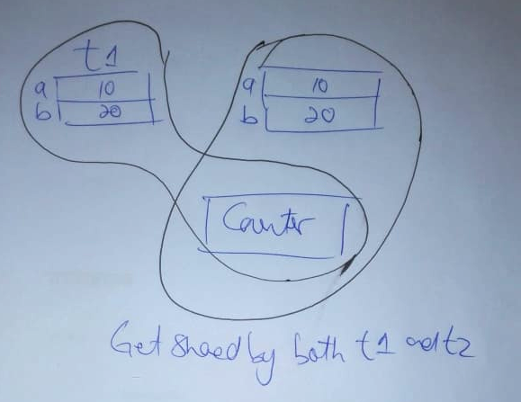

When talking about static members, we will be convering:

- Static Member (Data) Variables
- Static Member Functions

We know from before when defining a static data varianble inside a function, is like declaring a global variable (i.e. one that maintains its state), but local to that functon.

### Static Data Variable

We can do something similar for a data member (variable) inside a class. And it works the same (as one defined in normal local function).

How is it defined:

1. Inside the class with static keyword.

```
public:
    static int count;
```

1. But we also need to define it outside the class, using **scope resolution**

```
int Test::count=0;
```

And it also works the same as local static variable in function.

That is the it will be allocated memoery only once, even if class is instantiated multiple times, e.g.

```
Test t1
Test t2
```

So t1 and t2 (and any other objects) will share it.

So static data variable is on a **CLASS LEVEL**, NOT object level

This is provne with the following statement:

```
cout<Test::count<<endl;
```

That is static data variable belongs to class, but can be accessed using objects as well.'

### Using C++17

**Note** Using C++17 you can inline the static variable which removes the need to define it outside the class.

So we have to define:

```
static inline int count=0;
```

And the following DOES NOT work:

```
cout<Test::count<<endl;
```

Can only access it through object

```python
#include <iostream>
#include <climits>
#include <math.h>
using namespace std;
```

```python
class Test{
public:
    int a;
    int b;
//     static int count;
    static inline int count=0;
    Test(){
        a=10;
        b=20;
        count++;
    }

}
```

```python
// int Test::count=0;
```

```python
Test t1;
Test t2;
```

```python
// int Test::count=0;
```

```python
cout<<t1.count<<endl;
cout<<t2.count<<endl;
```

```
2
2
```